# COPD Summary Tables and Variable by Variable Analysis

Elise Hickman

Most recent revision date: 3/4/2024

# 1 Load packages

```r
# Clears global environment
rm(list = ls(all.names = TRUE))

# If needed, install and load packages
library(openxlsx) # for data import
library(janitor) # for data organization
library(tidyverse) # for data cleaning and organization
library(table1) # to make tables
library(rstatix) # for Dunn's test
library(FSA) # package that contains Dunn test function
library(DT) # for display of data tables
library(multcomp) #for Tukey's post hoc
library(ggfortify) # for PCA
library(factoextra) # for PCA
library(pheatmap) # for making heatmap
library(viridis) # for heatmap color scheme
```

# 2 Data Import and Organization

## 2.1 Soluble Mediator Data

Data import.

```r
# Import single-plex (sp) mediator data (md)
md_sp <- data.frame(read.xlsx("1_Raw_InputFiles/2022_04_19 COPD Mediator Data Single ELISAs.xlsx"))

# Import mesoscale (msd) mediator data (md)
md_msd <- data.frame(read.xlsx("1_Raw_InputFiles/2022_04_19 COPD Mediator Data MSD.xlsx"))

# Combine data from single-plex and MSD matricies
md <- left_join(md_sp, md_msd, by = "ExpSampleID")

# Remove unnecessary sample identification columns
md <- dplyr::select(md, -c(LAB_ID, ExpSampleID))
```

We realized after completing assays that some of the subjects were measured in duplicate. The below code averages the duplicates (manual calling of the specific subjects that were duplicates).

```r
# Extract rows from samples that have duplicate measurements
md_duplicates_avg <- filter(md, SubjectID == 'MU160833' |
                              SubjectID == 'SF181538' |
                              SubjectID == 'UT171009') %>% group_by(SubjectID) %>% summarize(across(everything(), mean))

# Remove rows from original data frame that contain data from the duplicate subjects
md <- md[!grepl("MU160833", md$SubjectID), ]
md <- md[!grepl("SF181538", md$SubjectID), ]
md <- md[!grepl("UT171009", md$SubjectID), ]

# Add back in averaged data for the duplicate samples
md <- bind_rows(md, md_duplicates_avg)
md <- data.frame(md[, -1], row.names = md$SubjectID)
```

Impute zeroes.

```r
# Impute zeroes as the sqrt of the lowest value in that column.
md <- as.data.frame(apply(md[ , 1:27], 2, function(x) replace(x, x == 0, sqrt(min(x[x>0])))))

# Filter out mediators that were detected in fewer than 27 subjects (~25% of the cohort, since we have four groups).
md <- md[, which(as.numeric(colSums(md != 0)) > 27)]

# Put column names in alphabetical order
md <- md[,order(names(md))]
```

## 2.2 Sputum Cell Differential Data

Initial import and filtering.

```r
# Import
diffs <- read.xlsx("1_Raw_InputFiles/2022_07_14 COPD Raw Diff Data.xlsx")

# Create vector of subject IDs to filter on
subject_ids <- row.names(md)

# Filter data to only include data from subjects of interest
diffs <- subset(diffs, SubjectID %in% subject_ids)
```

Calculate percentage and total counts based on non-squamous data as discussed with Dr. Alexis since initial input file didn’t calculate them correctly.

```r
# Calculate new percentage parameters

for (i in 3:7) {
  diffs$newcol <- diffs[[i]]/diffs[[10]]*100 # Divide count by total nonsquamous count, times 100
  cell <- strsplit(colnames(diffs)[i], split = "_") # Create variable for name of cell type
  cell <- noquote(cell[[1]][1]) # Create variable for name of cell type

  names(diffs)[names(diffs) == 'newcol'] <- noquote(paste0(cell, "_Perc")) # Rename column
}

# Calculate new total cell parameters

for (i in 15:19) {
  diffs$newcol <- diffs[[i]]/100*(diffs[[14]]-diffs[[13]]) # Multiply percentage by total cell count - squamous cell count
  cell <- strsplit(colnames(diffs)[i], split = "_") # Create variable for name of cell type
  cell <- noquote(cell[[1]][1]) # Create variable for name of cell type

  names(diffs)[names(diffs) == 'newcol'] <- noquote(paste0(cell, "_Count")) # Rename column
}


# Remove columns not of interest
diffs <- diffs[, -c(2:11)]
```

Average duplicates.

```r
# Make vector of subjects with two slides read
duplicated_diff_subjects <- diffs$SubjectID[duplicated(diffs$SubjectID)]

# Filter data frame to only include those subjects
duplicate_diffs <- subset(diffs, SubjectID %in% duplicated_diff_subjects)

# Average values
duplicate_diffs_avg <- duplicate_diffs %>% group_by(SubjectID) %>% summarize(across(c(1:13), mean))

# Remove duplicated rows and unnecessary columns in data frame, format data frame
diffs <- subset(diffs, !(SubjectID %in% duplicated_diff_subjects))
diffs <- bind_rows(diffs, duplicate_diffs_avg)
diffs <- data.frame(diffs[, -1], row.names = diffs$SubjectID)
```

## 2.3 Demographics Data

```r
# Import Data
demographics <- read.xlsx("1_Raw_InputFiles/2023_06_09 COPD Demographics.xlsx")

# Clean data frame and make new column for GOLD Stage as it will appear
demographics <- data.frame(demographics[, -1], row.names = demographics$SubjectID) %>%
  mutate("GoldStage" = recode(GoldStratum, "1" = "C", "2" = "p-COPD",
                                   "3" = "1/2", "4" = "3"))
```

# 3 Make demographics table

Prep for making table.

```r
# Identify factors that will be the columns in the table and specify the order they will appear.
demographics$Sex <- factor(demographics$Sex,
                           levels=c("M", "F"),
                           labels=c("Male", "Female"))

demographics$Race <- factor(demographics$Race,
                               levels=c("W", "B", "MO", "M"),
                               labels=c("White", "Black", "Mixed/Other", "Missing"))


demographics$GoldStage <- factor(demographics$GoldStage,
                            levels=c("C", "p-COPD", "1/2", "3"),
                            labels=c("Control", "Pre-COPD",
                                     "Mild/Moderate COPD (GOLD 1/2)", "Severe COPD (GOLD 3)"))

# Create row labels for variables of interest that need reformatting
label(demographics$PercPredFEV1) <- "% Predicted FEV1"
label(demographics$SmokingPackYears) <- "Smoking Pack Year History"
label(demographics$CurrentSmoker) <- "Current Smoker"
label(demographics$Cotinine) <- "Urine Cotinine"
label(demographics$GoldStageCOPDSev) <- "GOLD Stage"

# Determine whether continuous variabes are normally or non-normally distributed
shapiro.test(demographics$Age) # p-value = 0.01591 indicates non-normally distributed
```

```
##
##  Shapiro-Wilk normality test
##
## data:  demographics$Age
## W = 0.97048, p-value = 0.01591
```

```r
shapiro.test(demographics$BMI) # p-value = 0.06101 indicates normally distributed
```

```
##
##  Shapiro-Wilk normality test
##
## data:  demographics$BMI
## W = 0.97745, p-value = 0.06101
```

```r
shapiro.test(demographics$PercPredFEV1) # p-value = 3.593e-0.05 indicates non-normally distributed
```

```
##
##  Shapiro-Wilk normality test
##
## data:  demographics$PercPredFEV1
## W = 0.93252, p-value = 3.593e-05
```

```r
shapiro.test(demographics$SmokingPackYears) # p-value = 8.736e-05 indicates non-normally distributed
```

```
##
##  Shapiro-Wilk normality test
##
## data:  demographics$SmokingPackYears
## W = 0.9393, p-value = 8.736e-05
```

```r
shapiro.test(demographics$Cotinine) # p-value = 9.268e-15 indicates non-normally distributed
```

```
##
##  Shapiro-Wilk normality test
##
## data:  demographics$Cotinine
## W = 0.64962, p-value = 9.268e-15
```

```r
# Create function for custom table so that Mean (SD) is shown for continuous variables
my.render.cont <- function(x) {
  with(stats.apply.rounding(stats.default(x), digits=2), c("",
                                                           "Mean (SD)"=sprintf("%s (&plusmn; %s)", MEAN, SD)))
}


# Function for adding p-values to table
pvalue <- function(x, ...) {
  # Construct vectors of data y, and groups (strata) g
  y <- unlist(x)
  g <- factor(rep(1:length(x), times=sapply(x, length)))
  if (is.numeric(y)) {
    # For numeric variables, perform a non-parametric multiple comparisons test (Kruskal Wallis)
    p <- kruskal.test(y ~ g)$p.value
  } else {
    # For categorical variables, perform a Fisher's exact test (or Chi squared if there are expected frequencies >5)
    # Simulate p value = TRUE added because groups are too small
    p <- fisher.test(table(y, g), simulate.p.value = TRUE)$p.value
  }
  # Format the p-value, using an HTML entity for the less-than sign.
  # The initial empty string places the output on the line below the variable label.
  c("", sub("<", "&lt;", format.pval(p, digits=3, eps=0.001)))
}
```

Make table.

```r
# Must set seed when fisher's exact test has simulate = TRUE
set.seed(8016)

# Make table of demographics.
demotable <- table1(~ Sex + Race + Hispanic + Age + BMI + PercPredFEV1 + SmokingPackYears + CurrentSmoker + Cotinine  | GoldStage,
       data = demographics,
       render.continuous = my.render.cont,
       overall = NULL,
       extra.col = list(`P-value` = pvalue))

demotable
```

|  | Control (N=25) | Pre-COPD (N=26) | Mild/Moderate COPD (GOLD 1/2) (N=29) | Severe COPD (GOLD 3) (N=29) | P-value |
| --- | --- | --- | --- | --- | --- |
| Sex |  |  |  |  |  |
| Male | 12 (48.0%) | 15 (57.7%) | 15 (51.7%) | 14 (48.3%) | 0.898 |
| Female | 13 (52.0%) | 11 (42.3%) | 14 (48.3%) | 15 (51.7%) |  |
| Race |  |  |  |  |  |
| White | 13 (52.0%) | 20 (76.9%) | 21 (72.4%) | 19 (65.5%) | 0.099 |
| Black | 9 (36.0%) | 6 (23.1%) | 5 (17.2%) | 5 (17.2%) |  |
| Mixed/Other | 3 (12.0%) | 0 (0%) | 1 (3.4%) | 5 (17.2%) |  |
| Missing | 0 (0%) | 0 (0%) | 2 (6.9%) | 0 (0%) |  |
| Hispanic |  |  |  |  |  |
| No | 22 (88.0%) | 26 (100%) | 26 (89.7%) | 28 (96.6%) | 0.265 |
| Yes | 3 (12.0%) | 0 (0%) | 3 (10.3%) | 1 (3.4%) |  |
| Age |  |  |  |  |  |
| Mean (SD) | 58 (± 11) | 60 (± 12) | 66 (± 7.2) | 62 (± 8.9) | 0.0212 |
| BMI |  |  |  |  |  |
| Mean (SD) | 29 (± 5.5) | 32 (± 5.0) | 28 (± 5.4) | 27 (± 6.4) | 0.0477 |
| % Predicted FEV1 |  |  |  |  |  |
| Mean (SD) | 100 (± 12) | 87 (± 13) | 65 (± 16) | 37 (± 3.7) | <0.001 |
| Missing | 1 (4.0%) | 0 (0%) | 0 (0%) | 0 (0%) |  |
| Smoking Pack Year History |  |  |  |  |  |
| Mean (SD) | 0.0010 (± 0.0050) | 46 (± 20) | 57 (± 25) | 56 (± 26) | <0.001 |
| Current Smoker |  |  |  |  |  |
| No | 25 (100%) | 16 (61.5%) | 13 (44.8%) | 17 (58.6%) | <0.001 |
| Yes | 0 (0%) | 10 (38.5%) | 15 (51.7%) | 12 (41.4%) |  |
| Missing | 0 (0%) | 0 (0%) | 1 (3.4%) | 0 (0%) |  |
| Urine Cotinine |  |  |  |  |  |
| Mean (SD) | 7.4 (± 37) | 390 (± 550) | 720 (± 980) | 470 (± 570) | <0.001 |

Code for manually adding additional significance markers to demographics table for continuous variables.

```r
# Function to add significant numbers to data frame
signif.num <- function(x) {
  symnum(x, corr = FALSE, na = FALSE, legend = FALSE,
         cutpoints = c(0, 0.001, 0.01, 0.05, 0.1, 1),
         symbols = c("***", "**", "*", "+", " "))
}

# Function for Dunn test and nicely formatted results
dunn.test <- function(variable, group, data) {
  res <- dunnTest(as.formula(paste0(variable, "~", group)), data = data, method = "bh")
  res <- data.frame(res$res)
  res <- format(res, scientific = FALSE)
  res$AdjSignif <- signif.num(as.numeric(res$P.adj))
  res
}

AgeDunnRes <- dunn.test("Age", "GoldStage", demographics)
BMIDunnRes <- dunn.test("BMI", "GoldStage", demographics)
FEV1DunnRes <- dunn.test("PercPredFEV1", "GoldStage", demographics)
PackYrDunnRes <- dunn.test("SmokingPackYears", "GoldStage", demographics)
CotinineDunnRes <- dunn.test("Cotinine", "GoldStage", demographics)
```

# 4 Further subject characteristic exploration

Determine whether urine cotinine values seem to match whether a subject was classified as a current smoker or nonsmoker.

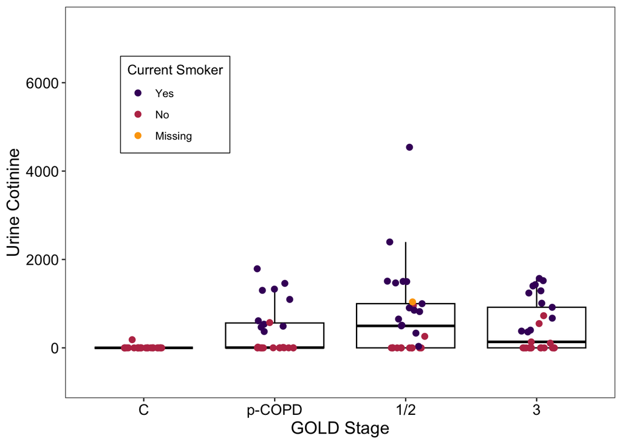

```r
theme_set(theme_bw())

demographics$CurrentSmoker <- factor(demographics$CurrentSmoker, c("Yes", "No", "Missing"))

demographics$GoldStage <- factor(demographics$GoldStage,
                            levels=c("Control", "Pre-COPD",
                                     "Mild/Moderate COPD (GOLD 1/2)", "Severe COPD (GOLD 3)"),
                            labels=c("C", "p-COPD","1/2", "3"))

smoker_cotinine_plot <- ggplot(demographics, aes (x = GoldStage, y = Cotinine)) +
  geom_boxplot(color = "black",
               outlier.shape = NA) +
  geom_jitter(position = position_jitter(0.15),
              aes(color = CurrentSmoker),
              size = 2) +
  labs(y = "Urine Cotinine", x = "GOLD Stage") +
  scale_y_continuous(expand = expansion(mult = c(0.25, 0.7))) +
  theme(axis.text.x = element_text(size = 12, color = "black"),
        axis.text.y = element_text(size = 12, color = "black"),
        axis.title.y = element_text(size = 14),
        axis.title.x = element_text (size = 14),
        legend.position = c(0.2, 0.75),
        legend.background = element_rect(fill = "white",
                                         size = 0.3,
                                         linetype = "solid",
                                         color = "black"),
        panel.grid.major = element_blank(),
        panel.grid.minor = element_blank()) +
  scale_color_viridis_d(name = "Current Smoker", begin = 0.2, end = 0.8, option = "B")
smoker_cotinine_plot
```

# 5 Analysis of between-group differences in sputum cell differentials

## 5.1 Assess normality of raw differential data

Normality can be assessed in multiple ways - through statistical testing or manual examination of histograms (qqplots can also be used).

Statistical testing of normality for each sputum metric indicates that data are not normally distributed (as expected).

```r
# Test normality of each sputum metric
diff_normality <- apply(diffs, 2, shapiro.test)

# Create data frame to summarize results
diff_normality <- do.call(rbind.data.frame, diff_normality)
diff_normality <- format(diff_normality, scientific = FALSE)

# Add column to adjust for multiple hypothesis testing
diff_normality$p.value.adj <- p.adjust(diff_normality$p.value, "BH")

# Add column for normality conclusion
diff_normality <- diff_normality %>% mutate(normal = ifelse(p.value.adj < 0.05, F, T))

datatable(diff_normality)
```

|  | statistic | p.value | method | data.name | p.value.adj | normal |
| --- | --- | --- | --- | --- | --- | --- |
| SEC_Perc | 0.9161013 | 0.000003829249209384888174592 | Shapiro-Wilk normality test | newX[, i] | 4.525476338363958e-06 | False |
| SEC_Count | 0.7024405 | 0.000000000000201914943891893 | Shapiro-Wilk normality test | newX[, i] | 2.768690936662209e-13 | False |
| TCCwSEC | 0.4214854 | 0.000000000000000001222485797 | Shapiro-Wilk normality test | newX[, i] | 3.1784630722e-18 | False |
| PMN_Perc | 0.9314136 | 0.000028442392696999971914715 | Shapiro-Wilk normality test | newX[, i] | 2.844239269699997e-05 | False |
| MacMono_Perc | 0.9194519 | 0.000005834630857287133608212 | Shapiro-Wilk normality test | newX[, i] | 6.320850095394394e-06 | False |
| Eos_Perc | 0.4615212 | 0.000000000000000003400932608 | Shapiro-Wilk normality test | newX[, i] | 6.316017700571429e-18 | False |
| Lym_Perc | 0.4001159 | 0.000000000000000000404111719 | Shapiro-Wilk normality test | newX[, i] | 1.31336308675e-18 | False |
| BEC_Perc | 0.5973779 | 0.000000000000000792307874320 | Shapiro-Wilk normality test | newX[, i] | 1.28750029577e-15 | False |
| PMN_Count | 0.3438790 | 0.000000000000000000098529566 | Shapiro-Wilk normality test | newX[, i] | 4.269614526666666e-19 | False |
| MacMono_Count | 0.7034043 | 0.000000000000212976225897093 | Shapiro-Wilk normality test | newX[, i] | 2.768690936662209e-13 | False |

[output cut: 3 more lines]

Histograms also demonstrate that data are not normally distributed.

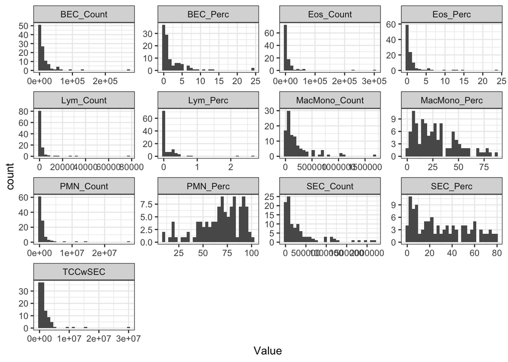

```r
diffs_histograms <- diffs %>% pivot_longer(all_of(colnames(diffs)), names_to = "Variable", values_to = "Value") %>%
  ggplot(aes(Value)) +
  geom_histogram() +
  facet_wrap(~ Variable, scales = "free")

diffs_histograms
```

## 5.2 Summary table of raw differential data

Prepare data frame:

```r
# Merge diff data and gold stratum
diffs_table <- transform(merge(diffs %>% dplyr::select(-c(SEC_Count, SEC_Perc)), demographics, by = 0), row.names=Row.names, Row.names = NULL)
```

Make summary table of means and SDs.

```r
# Calculate means
diffs_table_means <- diffs_table %>%
  group_by(GoldStage) %>%
  summarise(across(1:11, mean, na.rm = TRUE)) %>%
  pivot_longer(!GoldStage, names_to = "Variable", values_to = "Value") %>%
  mutate(Value = ifelse(Value > 1000, round(Value, digits = 0), round(Value, digits = 2))) %>%
  mutate(Value = format(Value, big.mark = ",")) %>%
  mutate(Value = case_when(grepl(".00", Value) ~ sub(".0+$", "", Value), .default = as.character(Value))) %>%
  mutate(Value = trimws(Value)) %>%
  rename("mean" = "Value") %>%
  unite("GoldStage_Variable", GoldStage, Variable, sep = "_", remove = FALSE)
# Store plus/minus character
x<-"\u00b1"
Encoding(x)<-"UTF-8"
start_paren <- paste0("(", x, " ", sep = "")

# Calculate standard deviations
diffs_table_sd <- diffs_table %>%
  group_by(GoldStage) %>%
  summarise(across(1:11, sd, na.rm = TRUE)) %>%
  pivot_longer(!GoldStage, names_to = "Variable", values_to = "Value") %>%
  mutate(Value = ifelse(Value > 1000, round(Value, digits = 0), round(Value, digits = 2))) %>%
  mutate(Value = format(Value, big.mark = ",")) %>%
  mutate(Value = case_when(grepl(".00", Value) ~ sub(".0+$", "", Value), .default = as.character(Value))) %>%
  mutate(Value = trimws(Value)) %>%
  mutate(Value = paste0(start_paren, Value, ")", sep ="")) %>%
  rename("SD" = "Value") %>%
  unite("GoldStage_Variable", GoldStage, Variable, sep = "_", remove = FALSE)

# Combine data frames and reformat
diffs_table_summarystats <- left_join(diffs_table_means,
                                      diffs_table_sd %>% dplyr::select(c(GoldStage_Variable, SD)),
                                      by = "GoldStage_Variable") %>%
  unite("Mean_SD", mean, SD, sep = " ", remove = TRUE) %>%
  dplyr::select(-c(GoldStage_Variable)) %>%
  pivot_wider(names_from = GoldStage, values_from = Mean_SD)
```

Perform Kruskal-Wallis test to determine overall significant differences between groups.

```r
# Perform Kruskal-Wallis test
kruskal_res <- diffs_table %>%
  dplyr::select(c(TCCwSEC:BEC_Count, GoldStage)) %>%
  pivot_longer(!GoldStage, names_to = "Variable", values_to = "Value") %>%
  group_by(Variable) %>%
  do(tidy(kruskal.test(x = .$Value, g = .$GoldStage))) %>%
  dplyr::select(c(Variable, p.value)) %>%
  rename("p-value" = "p.value")

# Apply BH correction
kruskal_res$`Adjusted p-value` <- p.adjust(kruskal_res$`p-value`, method = "BH")
```

Merge summary data frame and overall p-value data frame.

```r
# Create data frame
diffs_summary_table_final <- left_join(diffs_table_summarystats,
                                       kruskal_res %>% dplyr::select(c("Adjusted p-value", "Variable")),
                                                                     by = "Variable")

# Write out data frame
write.xlsx(diffs_summary_table_final, file = "2_OutputTables/DifferentialDataSummaryTable.xlsx")
```

Perform Dunn’s post hoc to determine significance of between-group comparisons.

```r
# Create variable and group names
diffs_table$GoldStage <- factor(diffs_table$GoldStage,
                            levels=c("C", "p-COPD", "1/2", "3"),
                            labels=c("Control", "Pre-COPD","GOLD 1/2", "GOLD 3"))

groups <- names(diffs_table)[28]
variables_diffs <- names(diffs_table) [1:11]

# Perform Dunn's test
DiffDunnTestRes <- lapply(variables_diffs, function(x) {
  rstatix::dunn_test(diffs_table, reformulate(groups, x),
                     p.adjust.method = "BH")
})

# Summarize results
DiffDunnRes <- data.frame()

for (i in 1:length(variables_diffs)) {
  data <- data.frame(DiffDunnTestRes[[i]])
  DiffDunnRes <- bind_rows(data, DiffDunnRes)
}

DiffDunnResTrimmed <- filter(DiffDunnRes, p.adj.signif != "ns")

DiffDunnRes_forpaper <- DiffDunnRes %>%
  dplyr::select(-c(n1, n2, statistic, p, p.adj.signif)) %>%
  unite(Comparison, group1, group2, sep = " - ") %>%
  mutate(p.adj = round(p.adj, digits = 6)) %>%
  pivot_wider(names_from = '.y.', values_from = p.adj) %>%
  t() %>% as.data.frame() %>%
  row_to_names(row_number = 1) %>%
  mutate(across(everything(), as.numeric)) %>%
  rownames_to_column("Variable")

# Create workbook to store these results and other statistical results for the supplementary tables
wb <- createWorkbook()

# Create bold style for workbook
bold <- createStyle(textDecoration = "bold")

# Add worksheet and format worksheet for these results
addWorksheet(wb, "Diffs_Dunn_Results")
writeData(wb, "Diffs_Dunn_Results", DiffDunnRes_forpaper)
conditionalFormatting(wb, sheet = "Diffs_Dunn_Results",
                      cols = 2:6, rows = 2:12, rule = "<0.05", style = bold)

# Write out table for paper.
saveWorkbook(wb, "2_OutputTables/Variable_by_Variable_Supplemental_Results.xlsx", overwrite = TRUE)
```

## 5.3 Assessment of squamous epithelial cell data

Squamous epithelial cell percentages are considered to be an indicator of sample quality - too high of a squamous epithelial cell percentage can indicate that the sample was derived more from the upper airways than the central airways. Different cutoffs are used; we used a cutoff of <80% when selecting our samples initially.

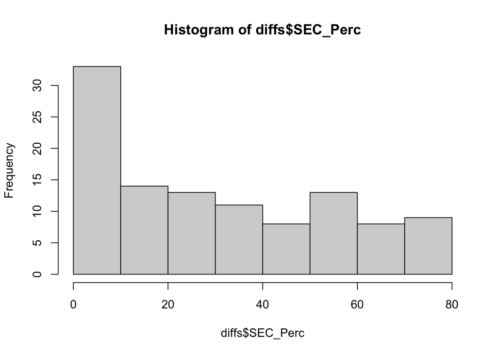

```r
squam <- mean(diffs$SEC_Perc)
squam_sem <- (sd(diffs$SEC_Perc))/(sqrt(length(diffs$SEC_Perc)))
squam_max <- max(diffs$SEC_Perc)
hist(diffs$SEC_Perc)
```

## 5.4 ANCOVA on cell differential data

ANCOVA will allow us to determine significant differences between group for each mediator while accounting for covariates. Choosing covariates is subjective, but here I included those that were significantly different in the demographics table, plus sex because of known differences between male and female airway immune responses and biology.

$~$

First, data are log transformed to move data closer to a normal distribution, as there isn’t a non-parametric alternative to ANCOVA.

```r
# Remove columns we aren't interested in (squamous epithelial cells)
diffs <- diffs[ , -c(1:2)]

# Add one to every data in the matrix and log2 transform to avoid negative values.
DiffDataLog <- log2(diffs[1:11]+1)

# Test normality of each sputum metric
DiffNormLog <- apply(DiffDataLog, 2, shapiro.test)

# Create data frame to summarize results
DiffNormLog <- do.call(rbind.data.frame, DiffNormLog)
DiffNormLog <- format(DiffNormLog, scientific = FALSE)

# Add column to adjust for multiple hypothesis testing
DiffNormLog$p.value.adj <- p.adjust(DiffNormLog$p.value, "BH")

# Add column for normality conclusion
DiffNormLog <- DiffNormLog %>% mutate(normal = ifelse(p.value.adj < 0.05, F, T))

datatable(DiffNormLog)
```

|  | statistic | p.value | method | data.name | p.value.adj | normal |
| --- | --- | --- | --- | --- | --- | --- |
| TCCwSEC | 0.9728181 | 0.0270564539653022004262 | Shapiro-Wilk normality test | newX[, i] | 0.02976209936183243 | False |
| PMN_Perc | 0.7738536 | 0.0000000000115818377844 | Shapiro-Wilk normality test | newX[, i] | 3.18500539071e-11 | False |
| MacMono_Perc | 0.9590140 | 0.0020020720104459094682 | Shapiro-Wilk normality test | newX[, i] | 0.002446976901656111 | False |
| Eos_Perc | 0.7536638 | 0.0000000000030963315476 | Shapiro-Wilk normality test | newX[, i] | 1.135321567453333e-11 | False |
| Lym_Perc | 0.5438291 | 0.0000000000000000802137 | Shapiro-Wilk normality test | newX[, i] | 8.823507e-16 | False |
| BEC_Perc | 0.8869753 | 0.0000001383271792502884 | Shapiro-Wilk normality test | newX[, i] | 1.901998714691465e-07 | False |
| PMN_Count | 0.9751359 | 0.0420401018726762470967 | Shapiro-Wilk normality test | newX[, i] | 0.04204010187267625 | False |
| MacMono_Count | 0.8038545 | 0.0000000001255312728675 | Shapiro-Wilk normality test | newX[, i] | 2.497528941939166e-10 | False |
| Eos_Count | 0.8049647 | 0.0000000001362288513785 | Shapiro-Wilk normality test | newX[, i] | 2.497528941939166e-10 | False |
| Lym_Count | 0.6698659 | 0.0000000000000356161436 | Shapiro-Wilk normality test | newX[, i] | 1.958887898e-13 | False |

[output cut: 1 more lines]

$~$

Viewing histograms and Shapiro-Wilk p-values indicates that although log-transforming values does not make the data perfectly normal, it does get closer to normal.

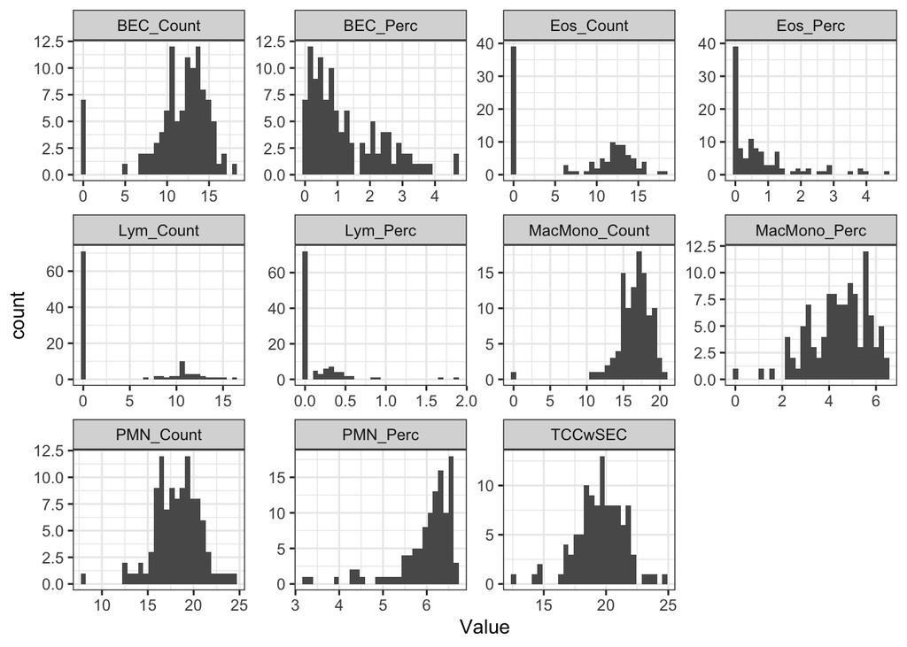

```r
diffs_log2_histograms <- DiffDataLog %>% pivot_longer(all_of(colnames(DiffDataLog)), names_to = "Variable", values_to = "Value") %>%
  ggplot(aes(Value)) +
  geom_histogram() +
  facet_wrap(~ Variable, scales = "free")

diffs_log2_histograms
```

Perform ANCOVA on cell differential data.

```r
# Merge back cell differential data with metadata
AllDiffDataLog <- transform(merge(demographics, DiffDataLog, by = 0), row.names=Row.names, Row.names = NULL)

# Remove demographics not of interest, order columns
AllDiffDataLog <- AllDiffDataLog %>%
  dplyr::select(-c(Hispanic, Race.Original, Race, PercPredFEV1, GoldStageCOPDSev, GoldStratum, SmokingPackYears,  Anabasine:NRNC))
AllDiffDataLog <- AllDiffDataLog %>% relocate(GoldStage)

# Create empty data frame
ANCOVAres_diffs = data.frame()

# Add row names to data frame so that it will be able to add ANCOVA results
rownames <- c("(Intercept)", "GoldStage", "BMI", "Age", "Sex", "CurrentSmoker", "Residuals")
ANCOVAres_diffs <- data.frame(cbind(rownames))

# Assign row names
ANCOVAres_diffs <- data.frame(ANCOVAres_diffs[, -1], row.names = ANCOVAres_diffs$rownames)

# Perform ANCOVA over all columns in
for (i in 6:ncol(AllDiffDataLog)) {

  fit = aov(as.formula(paste0(names(AllDiffDataLog)[i], "~", paste0("`", names(AllDiffDataLog[1:5]), "`", collapse="+"), sep = "")), AllDiffDataLog)
  res <- data.frame(car::Anova(fit, type="III"))
  res <- subset(res, select = Pr..F.)
  names(res)[names(res) == 'Pr..F.'] <- noquote(paste0(names(AllDiffDataLog[i])))

  ANCOVAres_diffs <- transform(merge(ANCOVAres_diffs, res, by = 0), row.names=Row.names, Row.names = NULL)
}

# Put columns in alphabetical order
ANCOVAres_diffs <- ANCOVAres_diffs[, order(names(ANCOVAres_diffs))]

# Transpose for easy viewing
ANCOVAres_diffs <- data.frame(t(ANCOVAres_diffs))

# Delete columns for intercept and residuals
ANCOVAres_diffs <- subset(ANCOVAres_diffs, select = c(GoldStage, Sex, Age, BMI, CurrentSmoker))
ANCOVAres_diffs_adj <- ANCOVAres_diffs %>%
  mutate(across(everything(), p.adjust, "BH"))

# Remove scientific notation and round
options(scipen = 999)
ANCOVAres_diffs_adj <- round(ANCOVAres_diffs_adj, 6)

# Add worksheet and format worksheet for these results
addWorksheet(wb, "Diffs_ANCOVA_Results")
writeData(wb, "Diffs_ANCOVA_Results", ANCOVAres_diffs_adj %>% rownames_to_column("Variable"))
conditionalFormatting(wb, sheet = "Diffs_ANCOVA_Results",
                      cols = 2:6, rows = 2:12, rule = "<0.05", style = bold)

# Write out table for paper.
saveWorkbook(wb, "2_OutputTables/Variable_by_Variable_Supplemental_Results.xlsx", overwrite = TRUE)
```

# 6 Analysis of between-group differences in induced sputum supernatant soluble mediators

## 6.1 Assess normality of raw mediator data

```r
# Test normality of each mediator
md_normality <- apply(md, 2, shapiro.test)

# Create data frame to summarize results
md_normality <- do.call(rbind.data.frame, md_normality)
md_normality <- format(md_normality, scientific = FALSE)

# Add column to adjust for multiple hypothesis testing
md_normality$p.value.adj <- p.adjust(md_normality$p.value, "BH")

# Add column for normality conclusion
md_normality <- md_normality %>% mutate(normal = ifelse(p.value.adj < 0.05, F, T))

datatable(md_normality)
```

|  | statistic | p.value | method | data.name | p.value.adj | normal |
| --- | --- | --- | --- | --- | --- | --- |
| ALB | 0.6440594 | 0.0000000000000070471944261456 | Shapiro-Wilk normality test | newX[, i] | 7.842298476172285e-15 | False |
| CC16 | 0.6372595 | 0.0000000000000050625183439664 | Shapiro-Wilk normality test | newX[, i] | 6.213090694867855e-15 | False |
| CRP | 0.2756999 | 0.0000000000000000000085583583 | Shapiro-Wilk normality test | newX[, i] | 3.04094304e-20 | False |
| Eotaxin | 0.4392162 | 0.0000000000000000015375015119 | Shapiro-Wilk normality test | newX[, i] | 2.59453380133125e-18 | False |
| Eotaxin3 | 0.2189021 | 0.0000000000000000000017399549 | Shapiro-Wilk normality test | newX[, i] | 1.1744695575e-20 | False |
| IL10 | 0.2486159 | 0.0000000000000000000039580341 | Shapiro-Wilk normality test | newX[, i] | 1.781115345e-20 | False |
| IL12p40 | 0.5734304 | 0.0000000000000002772003445094 | Shapiro-Wilk normality test | newX[, i] | 3.939162790396736e-16 | False |
| IL12p70 | 0.2920315 | 0.0000000000000000000137721259 | Shapiro-Wilk normality test | newX[, i] | 4.131637770000001e-20 | False |
| IL1a | 0.7126901 | 0.0000000000002636321797655366 | Shapiro-Wilk normality test | newX[, i] | 2.73771878987288e-13 | False |
| IL1B | 0.3663208 | 0.0000000000000000001341177916 | Shapiro-Wilk normality test | newX[, i] | 3.017650311e-19 | False |

[output cut: 17 more lines]

$~$

Histograms also demonstrate that data are not normally distributed.

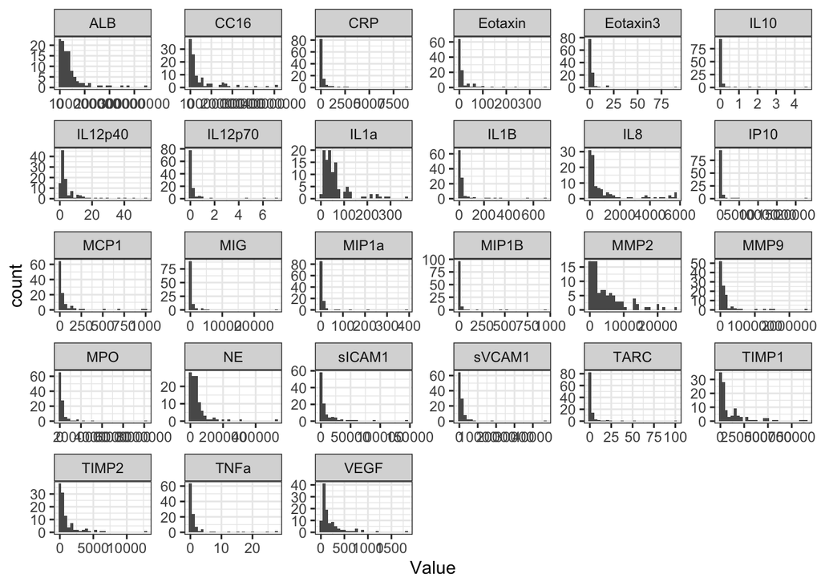

```r
md_histograms <- md %>% pivot_longer(all_of(colnames(md)), names_to = "Variable", values_to = "Value") %>%
  ggplot(aes(Value)) +
  geom_histogram() +
  facet_wrap(~ Variable, scales = "free")

md_histograms
```

## 6.2 Summary table of raw mediator data

Create summary values:

```r
# Merge mediator data and gold stratum
md <- transform(merge(md, demographics, by = 0), row.names=Row.names, Row.names = NULL) %>%
  dplyr::select(c(ALB:VEGF, GoldStage))

# Store plus/minus character
x<-"\u00b1"
Encoding(x)<-"UTF-8"
start_paren <- paste0("(", x, " ", sep = "")

# Calculate means
md_table_means <- md %>%
  group_by(GoldStage) %>%
  summarise(across(1:(ncol(md)-1), mean, na.rm = TRUE)) %>%
  pivot_longer(!GoldStage, names_to = "Variable", values_to = "Value") %>%
  mutate(Value = ifelse(Value > 1000, round(Value, digits = 0), round(Value, digits = 2))) %>%
  mutate(Value = format(Value, big.mark = ",")) %>%
  mutate(Value = case_when(grepl(".00", Value) ~ sub(".0+$", "", Value), .default = as.character(Value))) %>%
  mutate(Value = trimws(Value)) %>%
  rename("mean" = "Value") %>%
  unite("GoldStage_Variable", GoldStage, Variable, sep = "_", remove = FALSE)

# Calculate standard deviations
md_table_sd <- md %>%
  group_by(GoldStage) %>%
  summarise(across(1:(ncol(md)-1), sd, na.rm = TRUE)) %>%
  pivot_longer(!GoldStage, names_to = "Variable", values_to = "Value") %>%
  mutate(Value = ifelse(Value > 1000, round(Value, digits = 0), round(Value, digits = 2))) %>%
  mutate(Value = format(Value, big.mark = ",")) %>%
  mutate(Value = case_when(grepl(".00", Value) ~ sub(".0+$", "", Value), .default = as.character(Value))) %>%
  mutate(Value = trimws(Value)) %>%
  mutate(Value = paste0(start_paren, Value, ")", sep ="")) %>%
  rename("SD" = "Value") %>%
  unite("GoldStage_Variable", GoldStage, Variable, sep = "_", remove = FALSE)

# Combine data frames and reformat
md_table_summarystats <- left_join(md_table_means,
                                      md_table_sd %>% dplyr::select(c(GoldStage_Variable, SD)),
                                      by = "GoldStage_Variable") %>%
  unite("Mean_SD", mean, SD, sep = " ", remove = TRUE) %>%
  dplyr::select(-c(GoldStage_Variable)) %>%
  pivot_wider(names_from = GoldStage, values_from = Mean_SD)
```

Perform Kruskal-Wallis test to determine overall significant differences between groups.

```r
# Perform Kruskal-Wallis test
kruskal_res_md <- md %>%
  pivot_longer(!GoldStage, names_to = "Variable", values_to = "Value") %>%
  group_by(Variable) %>%
  do(tidy(kruskal.test(x = .$Value, g = .$GoldStage))) %>%
  dplyr::select(c(Variable, p.value)) %>%
  rename("p-value" = "p.value")

# Apply BH correction
kruskal_res_md$`Adjusted p-value` <- p.adjust(kruskal_res_md$`p-value`, method = "BH")
```

Merge summary data frame and overall p-value data frame.

```r
# Create data frame
md_summary_table_final <- left_join(md_table_summarystats,
                                       kruskal_res_md %>% dplyr::select(c("Adjusted p-value", "Variable")),
                                                                     by = "Variable") %>%
  rename("Kruskal-Wallis Adjusted P-value (Crude Approach)" = "Adjusted p-value")
```

Perform Dunn’s post hoc to determine significance of between-group comparisons and summarize in a table for paper supplement.

```r
# Create variable and group names
md$GoldStage <- factor(md$GoldStage,
                            levels=c("C", "p-COPD", "1/2", "3"),
                            labels=c("Control", "Pre-COPD","GOLD 1/2", "GOLD 3"))

# Create group and variable names
groups <- names(md)[28]
variables_mediators <- names(md %>% dplyr::select(-GoldStage))

# Run Dunn's Test
MediatorDunnTestRes <- lapply(variables_mediators, function(x) {
  rstatix::dunn_test(md, reformulate(groups, x),
                     p.adjust.method = "BH")
})

# Summarize Dunn Test results in one data frame
MediatorDunnRes <- data.frame()

for (i in 1:27) {
  res_df <- data.frame(MediatorDunnTestRes[[i]])
  MediatorDunnRes <- bind_rows(MediatorDunnRes, res_df)
}

# Format and export
MediatorDunnRes_forpaper <- MediatorDunnRes %>%
  dplyr::select(-c(n1, n2, statistic, p, p.adj.signif)) %>%
  unite(Comparison, group1, group2, sep = " - ") %>%
  mutate(p.adj = round(p.adj, digits = 7)) %>%
  pivot_wider(names_from = '.y.', values_from = p.adj) %>%
  t() %>% as.data.frame() %>%
  row_to_names(row_number = 1) %>%
  mutate(across(everything(), as.numeric)) %>%
  rownames_to_column("Variable")

# Add worksheet and format worksheet for these results
addWorksheet(wb, "Mediator_Dunn_Results")
writeData(wb, "Mediator_Dunn_Results", MediatorDunnRes_forpaper)
conditionalFormatting(wb, sheet = "Mediator_Dunn_Results",
                      cols = 2:6, rows = 2:28, rule = "<0.05", style = bold)

# Write out table for paper.
saveWorkbook(wb, "2_OutputTables/Variable_by_Variable_Supplemental_Results.xlsx", overwrite = TRUE)
```

## 6.3 ANCOVA on mediator data

ANCOVA will allow us to determine significant differences between group for each mediator while accounting for covariates. Choosing covariates is subjective, but here I included those that were significantly different in the demographics table, plus sex because of known differences between male and female airway immune responses and biology.

$~$

First, data are log transformed to move data closer to a normal distribution, as there isn’t a non-parametric alternative to ANCOVA.

```r
# Add one to every data in the matrix and log2 transform to avoid negative values.
md_log <- log2(md[1:27]+1)

# Test normality of each sputum metric
md_log_normality <- apply(md_log, 2, shapiro.test)

# Create data frame to summarize results
md_log_normality <- do.call(rbind.data.frame, md_log_normality)
md_log_normality <- format(md_log_normality, scientific = FALSE)

# Add column to adjust for multiple hypothesis testing
md_log_normality$p.value.adj <- p.adjust(md_log_normality$p.value, "BH")

# Add column for normality conclusion
md_log_normality <- md_log_normality %>% mutate(normal = ifelse(p.value.adj < 0.05, F, T))

datatable(md_log_normality)
```

|  | statistic | p.value | method | data.name | p.value.adj | normal |
| --- | --- | --- | --- | --- | --- | --- |
| ALB | 0.9575195 | 0.001549906605629597887430 | Shapiro-Wilk normality test | newX[, i] | 0.002615467396999946 | False |
| CC16 | 0.9635934 | 0.004477558429601696636524 | Shapiro-Wilk normality test | newX[, i] | 0.006740655911056898 | False |
| CRP | 0.9457086 | 0.000228786672708862086388 | Shapiro-Wilk normality test | newX[, i] | 0.0004118160108759517 | False |
| Eotaxin | 0.7854693 | 0.000000000025665412667362 | Shapiro-Wilk normality test | newX[, i] | 7.6996238002086e-11 | False |
| Eotaxin3 | 0.7424206 | 0.000000000001533504205611 | Shapiro-Wilk normality test | newX[, i] | 8.280922710299401e-12 | False |
| IL10 | 0.3297980 | 0.000000000000000000042766 | Shapiro-Wilk normality test | newX[, i] | 1.154682e-18 | False |
| IL12p40 | 0.9096067 | 0.000001736200084215498823 | Shapiro-Wilk normality test | newX[, i] | 4.261582024892588e-06 | False |
| IL12p70 | 0.4643509 | 0.000000000000000003767890 | Shapiro-Wilk normality test | newX[, i] | 5.0866515e-17 | False |
| IL1a | 0.9859647 | 0.312307821631056192757114 | Shapiro-Wilk normality test | newX[, i] | 0.366622225392979 | True |
| IL1B | 0.9351872 | 0.000048246866718116186918 | Shapiro-Wilk normality test | newX[, i] | 9.304752867065264e-05 | False |

[output cut: 17 more lines]

Viewing histograms and Shapiro-Wilk p-values indicates that although log-transforming values does not make the data perfectly normal, it does get closer to normal.

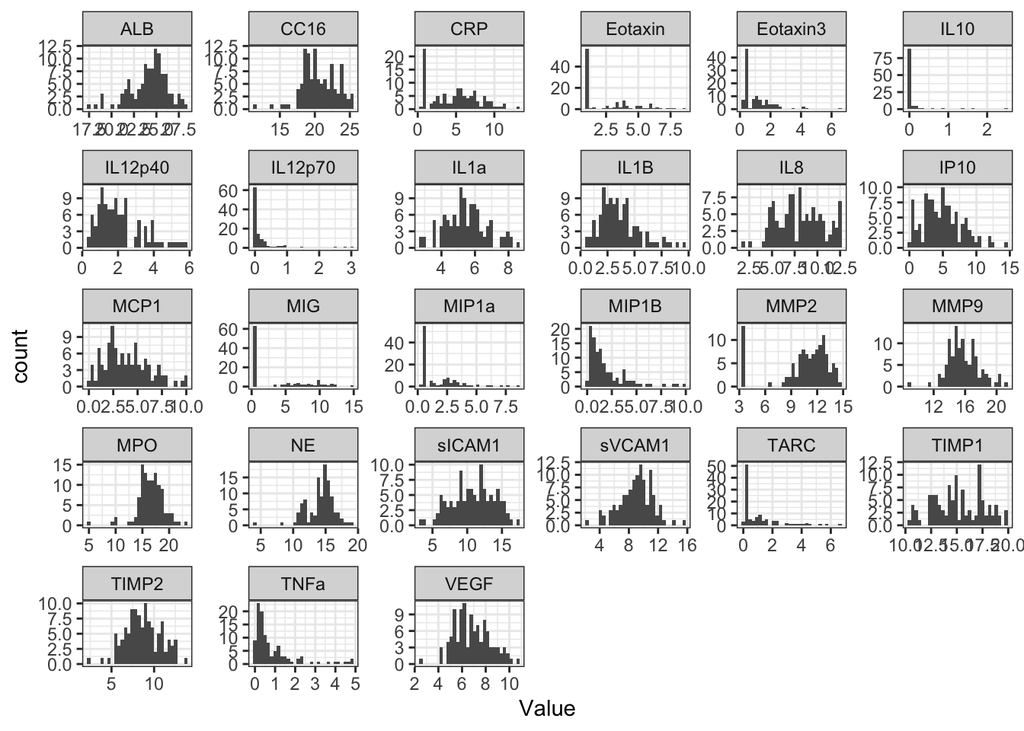

```r
mediators_log2_histograms <- md_log %>% pivot_longer(all_of(colnames(md_log)), names_to = "Variable", values_to = "Value") %>%
  ggplot(aes(Value)) +
  geom_histogram() +
  facet_wrap(~ Variable, scales = "free")

mediators_log2_histograms
```

$~$

Perform ANCOVA on mediator data.

```r
# Merge back metadata
md_log <- transform(merge(demographics %>% dplyr::select(c(BMI:Sex, GoldStage, CurrentSmoker)), md_log, by = 0), row.names=Row.names, Row.names = NULL) %>%
  relocate(GoldStage)

# Create empty data frame
ANCOVAres_mediators = data.frame()

# Add row names to data frame so that it will be able to add ANCOVA results
rownames <- c("(Intercept)", "GoldStage", "BMI", "Age", "Sex", "CurrentSmoker", "Residuals")
ANCOVAres_mediators <- data.frame(cbind(rownames))

# Assign row names
ANCOVAres_mediators <- data.frame(ANCOVAres_mediators[, -1], row.names = ANCOVAres_mediators$rownames)

# Perform ANCOVA over all columns in
for (i in 6:ncol(md_log)) {

  fit = aov(as.formula(paste0(names(md_log)[i], "~", paste0("`", names(md_log[1:5]), "`", collapse="+"), sep = "")), md_log)
  res <- data.frame(car::Anova(fit, type="III"))
  res <- subset(res, select = Pr..F.)
  names(res)[names(res) == 'Pr..F.'] <- noquote(paste0(names(md_log[i])))

  ANCOVAres_mediators <- transform(merge(ANCOVAres_mediators, res, by = 0), row.names=Row.names, Row.names = NULL)
}

# Put columns in alphabetical order
ANCOVAres_mediators <- ANCOVAres_mediators[, order(names(ANCOVAres_mediators))]

# Transpose for easy viewing
ANCOVAres_mediators <- data.frame(t(ANCOVAres_mediators))

# Delete columns for intercept and residuals
ANCOVAres_mediators <- subset(ANCOVAres_mediators, select = c(GoldStage, Sex, Age, BMI, CurrentSmoker))
ANCOVAres_mediators_adj <- ANCOVAres_mediators %>%
  mutate(across(everything(), p.adjust, "BH")) %>%
  rownames_to_column("Variable")

# Add worksheet and format worksheet for these results
addWorksheet(wb, "Mediator_ANCOVA_Results")
writeData(wb, "Mediator_ANCOVA_Results", ANCOVAres_mediators_adj)
conditionalFormatting(wb, sheet = "Mediator_ANCOVA_Results",
                      cols = 2:6, rows = 2:28, rule = "<0.05", style = bold)

# Write out table for paper.
saveWorkbook(wb, "2_OutputTables/Variable_by_Variable_Supplemental_Results.xlsx", overwrite = TRUE)
```

Add GoldStage column to the summary data table.

```r
# Combine ANCOVA results with Kruskal-Wallis results/summary table
md_summary_table_final <- md_summary_table_final %>%
  left_join(ANCOVAres_mediators_adj %>% dplyr::select(c(GoldStage, Variable)), by = "Variable") %>%
  rename("ANCOVA Adjusted P-Value (Adjusted Approach)" = "GoldStage")

# Add worksheet and format worksheet for these results
addWorksheet(wb, "Mediator_Summary_Table")
writeData(wb, "Mediator_Summary_Table", md_summary_table_final)
conditionalFormatting(wb, sheet = "Mediator_Summary_Table",
                      cols = 6:7, rows = 2:28, rule = "<0.05", style = bold)

# Write out table for paper.
saveWorkbook(wb, "2_OutputTables/Variable_by_Variable_Supplemental_Results.xlsx", overwrite = TRUE)
```

Perform Tukey’s post hoc to determine differences between specific groups.

```r
# Re-label stratum
md_log$GoldStage <- factor(md_log$GoldStage,
                            levels=c("C", "p-COPD", "1/2", "3"),
                            labels=c("Control", "Pre-COPD","GOLD 1/2", "GOLD 3"))

# Create empty data frame
MediatorsTukeyRes <- data.frame()

# Add row names to data frame so that it will be able to add ANCOVA results
rownames_tukey <- c("Pre-COPD - Control", "GOLD 1/2 - Control", "GOLD 3 - Control", "GOLD 1/2 - Pre-COPD", "GOLD 3 - Pre-COPD", "GOLD 3 - GOLD 1/2")
MediatorsTukeyRes <- data.frame(cbind(rownames_tukey))

# Assign row names
MediatorsTukeyRes <- data.frame(MediatorsTukeyRes[, -1], row.names = MediatorsTukeyRes$rownames_tukey)

# Perform Tukey test
for (i in 6:ncol(md_log)) {

  fit = aov(as.formula(paste0(names(md_log)[i], "~", paste0("`", names(md_log[1:5]), "`", collapse="+"), sep = "")),
            md_log)

  posthoc <- summary(glht(fit, linfct = mcp(GoldStage = "Tukey")), test = adjusted("BH"))

  res <- summary(posthoc)$test

  res_df <- data.frame(cbind (res$coefficients, res$sigma, res$tstat, res$pvalues))
  colnames(res_df) <- c("Estimate", "Std.Error", "t.value", "Pr(>|t|)")
  res_df <- res_df[4]
  names(res_df)[names(res_df) == 'Pr(>|t|)'] <- noquote(paste0(names(md_log[i])))

  MediatorsTukeyRes <- transform(merge(MediatorsTukeyRes, res_df, by = 0), row.names=Row.names, Row.names = NULL)
}

# Reformat results for paper
MediatorsTukeyRes_forpaper <- MediatorsTukeyRes %>%
  rownames_to_column("Comparison") %>%
  t() %>% as.data.frame() %>%
  row_to_names(row_number = 1) %>%
  mutate(across(everything(), as.numeric)) %>%
  rownames_to_column("Variable")

# Add worksheet and format worksheet for these results
addWorksheet(wb, "Mediator_ANCOVA_Tukey_Results")
writeData(wb, "Mediator_ANCOVA_Tukey_Results", MediatorsTukeyRes_forpaper)
conditionalFormatting(wb, sheet = "Mediator_ANCOVA_Tukey_Results",
                      cols = 2:6, rows = 2:28, rule = "<0.05", style = bold)

# Write out table for paper.
saveWorkbook(wb, "2_OutputTables/Variable_by_Variable_Supplemental_Results.xlsx", overwrite = TRUE)
```

## 6.4 Graphing a subset of (ANCOVA) statistically significant mediators

### 6.4.1 Visualize overall patterns in mediators

```r
# Filter mediators to only those that were statistically significant using ANCOVA. First, make a vector of proteins that had p < 0.05 for Gold Stratum in ANCOVA
ANCOVAres_mediators_signif <- ANCOVAres_mediators_adj %>%
  filter(GoldStage < 0.05)

ANCOVAres_mediators_signif <- ANCOVAres_mediators_signif$Variable

# Make pattern line chart to see whether all were the same pattern or not between groups
md_means_forgraph <- md %>%
  dplyr::select(c(ALB:VEGF, GoldStage)) %>%
  group_by(GoldStage) %>%
  summarise(across(everything(), mean, na.rm = TRUE)) %>%
  pivot_longer(!GoldStage, names_to = "Variable", values_to = "Value") %>%
  filter(Variable %in% ANCOVAres_mediators_signif) %>%
  mutate(GoldStage = recode(GoldStage, "Control" = "C", "Pre-COPD" = "P", "GOLD 1/2" = "1/2", "GOLD 3" = "3"))

mediator_lineplots <- ggplot(md_means_forgraph, aes(x = GoldStage, y = Value)) +
  geom_line(group = 1) +
  geom_point() +
  scale_y_continuous(expand = expansion(mult = c(0.25, 0.7))) +
  labs(y = "Concentration (pg/mL)",
       x = "Group") +
  facet_wrap(~Variable, scales = "free_y", nrow = 5) +
  theme(strip.text = element_text(size = 12, face = "bold"),
        axis.text.x = element_text(size = 9, color = "black"),
        axis.text.y = element_text(size = 8, color = "black"),
        axis.title.y = element_text(size = 10, margin = margin(t = 0, r = 10, b = 0, l = 0, unit = "pt")),
        axis.title.x = element_text(size = 10, margin = margin(t = 10, r = 0, b = 0, l = 0, unit = "pt")),
        legend.position = "none",
        panel.grid.major = element_blank(),
        panel.grid.minor = element_blank())

pdf("4_OutputFigs/SolubleMediatorLinePlot_Raw.pdf",
    colormodel = "cmyk",
    bg = "transparent",
    width = 6,
    height = 6)

mediator_lineplots

invisible(dev.off())
```

Preparations for graphing:

```r
md_log_forgraph <- md_log %>%
  dplyr::select(c(GoldStage, all_of(ANCOVAres_mediators_signif))) %>%
  pivot_longer(!GoldStage, names_to = "Variable", values_to = "Value")

heights_forgraph <- md_log_forgraph %>%
  group_by(Variable) %>%
  mutate(height = max(Value) * 1.5) %>%
  unite(Comparison_Variable, GoldStage, Variable, sep = "_")

label_df <- MediatorsTukeyRes %>%
  dplyr::select(all_of(ANCOVAres_mediators_signif)) %>%
  rownames_to_column("Comparison") %>%
  separate(Comparison, into = c("g1", "g2"), sep = " - ")

label_df_s1 <- label_df %>%
  filter(g1 == "Control" | g2 == "Control") %>%
  mutate_all(~gsub("Control", "", .)) %>%
  unite(Comparison, g1, g2, sep = "") %>%
  add_row(Comparison = "Control") %>%
  pivot_longer(!Comparison, names_to = "Variable", values_to = "Value") %>%
  mutate(Value = ifelse(Value < 0.05, "C", "")) %>%
  mutate(Value = replace_na(Value, "")) %>%
  unite(Comparison_Variable, Comparison, Variable, sep = "_") %>%
  rename("Value_1" = "Value")

label_df_s2 <- label_df %>%
  filter(g1 == "Pre-COPD" | g2 == "Pre-COPD") %>%
  mutate_all(~gsub("Pre-COPD", "", .)) %>%
  unite(Comparison, g1, g2, sep = "") %>%
  add_row(Comparison = "Pre-COPD") %>%
  pivot_longer(!Comparison, names_to = "Variable", values_to = "Value") %>%
  mutate(Value = ifelse(Value < 0.05, "P", "")) %>%
  mutate(Value = replace_na(Value, "")) %>%
  unite(Comparison_Variable, Comparison, Variable, sep = "_") %>%
  rename("Value_2" = "Value")

label_df_s3 <- label_df %>%
  filter(g1 == "GOLD 1/2" | g2 == "GOLD 1/2") %>%
  mutate_all(~gsub("GOLD 1/2", "", .)) %>%
  unite(Comparison, g1, g2, sep = "") %>%
  add_row(Comparison = "GOLD 1/2") %>%
  pivot_longer(!Comparison, names_to = "Variable", values_to = "Value") %>%
  mutate(Value = ifelse(Value < 0.05, "1/2", "")) %>%
  mutate(Value = replace_na(Value, "")) %>%
  unite(Comparison_Variable, Comparison, Variable, sep = "_") %>%
  rename("Value_3" = "Value")

label_df_s4 <- label_df %>%
  filter(g1 == "GOLD 3" | g2 == "GOLD 3") %>%
  mutate_all(~gsub("GOLD 3", "", .)) %>%
  unite(Comparison, g1, g2, sep = "") %>%
  add_row(Comparison = "GOLD 3") %>%
  pivot_longer(!Comparison, names_to = "Variable", values_to = "Value") %>%
  mutate(Value = ifelse(Value < 0.05, "3", "")) %>%
  mutate(Value = replace_na(Value, "")) %>%
  unite(Comparison_Variable, Comparison, Variable, sep = "_") %>%
  rename("Value_4" = "Value")

all_dfs <- list(label_df_s1, label_df_s2, label_df_s3, label_df_s4)

# Combine data frames using reduce function. Then combine each column to make labels.
label_df_final <- all_dfs %>%
  reduce(full_join, by = "Comparison_Variable") %>%
  mutate_if(is.character, list(~na_if(.,""))) %>%
  unite(Label, Value_1, Value_2, Value_3, Value_4, sep = ",", na.rm = TRUE) %>%
  left_join(heights_forgraph %>% dplyr::select(-Value), by = "Comparison_Variable") %>%
  separate(Comparison_Variable, into = c("Comparison", "Variable"), sep = "_") %>%
  rename("GoldStage" = "Comparison") %>%
  mutate(Label = ifelse(GoldStage == "Control", "", Label)) %>% # Remove labels for stratum 1 since they are duplicates
  mutate(Label = ifelse(Label == "3", "", Label)) # Remove label for if only group 4 is significant, as this will be captured by other labels
```

Now we can make a graph with the annotations. Here, increased in stratum 4 only:

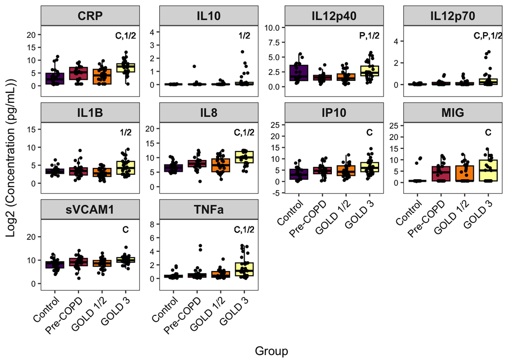

```r
# Increased in stratum 4 only
s4only_variables <- c("CRP", "IL10", "IL12p40", "IL12p70", "IL1B", "IL8", "IP10", "MIG", "sVCAM1", "TNFa")

md_log_forgraph_s4only <- md_log_forgraph %>%
  filter(Variable %in% s4only_variables)

label_df_final_s4only <- label_df_final %>%
  filter(Variable %in% s4only_variables)

# Make graph
theme_set(theme_bw())

mediator_figurepanel_withsig_s4only <- ggplot(md_log_forgraph_s4only) +
  geom_boxplot(aes(x = GoldStage, y = Value, fill = GoldStage), color = "black", outlier.shape = NA) +
  geom_jitter(aes(x = GoldStage, y = Value, fill = GoldStage), position = position_jitter(0.15),
              shape = 20) +
  geom_text(data = label_df_final_s4only, aes(x = GoldStage, y = height,
                                       label = paste0(Label)), size = 3) +
  labs(y = "Log2 (Concentration (pg/mL))",
       x = "Group") +
  facet_wrap( ~Variable, scales = "free_y", nrow = 3) +
  scale_y_continuous(expand = expansion(mult = c(0.25, 0.2))) +
  theme(strip.text = element_text(size = 12, face = "bold"),
        axis.text.x = element_text(size = 10, color = "black", angle = 45, hjust = 1),
        axis.text.y = element_text(size = 8, color = "black"),
        axis.title.y = element_text(size = 12, margin = margin(t = 0, r = 10, b = 0, l = 0, unit = "pt")),
        axis.title.x = element_text(size = 12, margin = margin(t = 10, r = 0, b = 0, l = 0, unit = "pt")),
        legend.position = "none",
        panel.grid.major = element_blank(),
        panel.grid.minor = element_blank()) +
  scale_fill_viridis_d(begin = 0.25, end = 1, option = "B")

mediator_figurepanel_withsig_s4only
```

```r
pdf("4_OutputFigs/SolubleMediatorFigurePanel_LogTransformed_WithSig_S4Only.pdf",
    colormodel = "cmyk",
    bg = "transparent",
    width = 9,
    height = 6)

mediator_figurepanel_withsig_s4only

invisible(dev.off())
```

Now we can make a graph with the annotations. Here, increased in stratum 2 and 4:

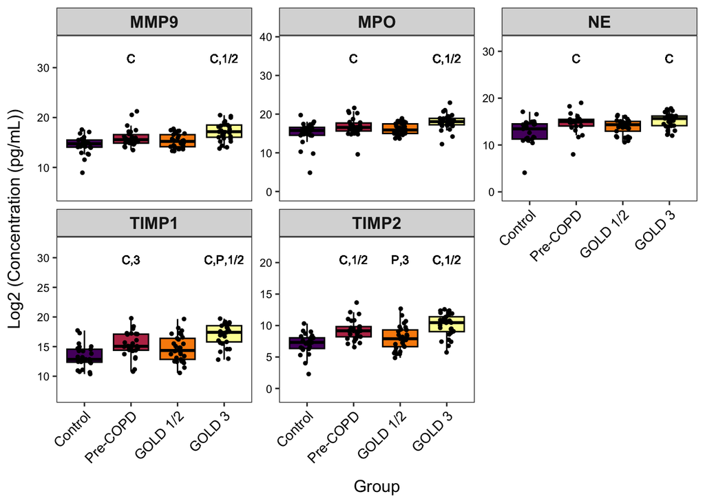

```r
# Increased in stratum 4 only
s2s4_variables <- c("MMP9", "MPO", "NE", "TIMP1", "TIMP2")

md_log_forgraph_s2s4 <- md_log_forgraph %>%
  filter(Variable %in% s2s4_variables)

label_df_final_s2s4 <- label_df_final %>%
  filter(Variable %in% s2s4_variables)

# Make graph
theme_set(theme_bw())

mediator_figurepanel_withsig_s2s4 <- ggplot(md_log_forgraph_s2s4) +
  geom_boxplot(aes(x = GoldStage, y = Value, fill = GoldStage), color = "black", outlier.shape = NA) +
  geom_jitter(aes(x = GoldStage, y = Value, fill = GoldStage), position = position_jitter(0.15),
              shape = 20) +
  geom_text(data = label_df_final_s2s4, aes(x = GoldStage, y = height,
                                       label = paste0(Label)), size = 3) +
  labs(y = "Log2 (Concentration (pg/mL))",
       x = "Group") +
  facet_wrap( ~Variable, scales = "free_y", nrow = 2, ncol = 3) +
  scale_y_continuous(expand = expansion(mult = c(0.25, 0.2))) +
  theme(strip.text = element_text(size = 12, face = "bold"),
        axis.text.x = element_text(size = 10, color = "black", angle = 45, hjust = 1),
        axis.text.y = element_text(size = 8, color = "black"),
        axis.title.y = element_text(size = 12, margin = margin(t = 0, r = 10, b = 0, l = 0, unit = "pt")),
        axis.title.x = element_text(size = 12, margin = margin(t = 10, r = 0, b = 0, l = 0, unit = "pt")),
        legend.position = "none",
        panel.grid.major = element_blank(),
        panel.grid.minor = element_blank()) +
  scale_fill_viridis_d(begin = 0.25, end = 1, option = "B")

mediator_figurepanel_withsig_s2s4
```

```r
pdf("4_OutputFigs/SolubleMediatorFigurePanel_LogTransformed_WithSig_S2S4.pdf",
    colormodel = "cmyk",
    bg = "transparent",
    width = 6,
    height = 4.25)

mediator_figurepanel_withsig_s2s4

invisible(dev.off())
```

# 7 Write out file needed for predictive modeling code.

```r
write.xlsx(md %>% rownames_to_column("SubjectID"), file = "5_ProcessedData/processed_md_data.xlsx")
```